# Joel_IVRS_Script

Harun

2022-06-08

## Exploration of the Iowa Vocational Rehabilitation Services (IVRS) Data

This data comes from the data.iowa.gov website and provides information on closed cases where the individual received services from IVRS. This data includes cases closed after October 1, 2008.

## Number of Cases by Gender

This section looks at the number of cases for each gender.

From this graph we can see that there were more cases for men although it can be noted that the number of cases for women isn’t to far off from the total of men’s cases.

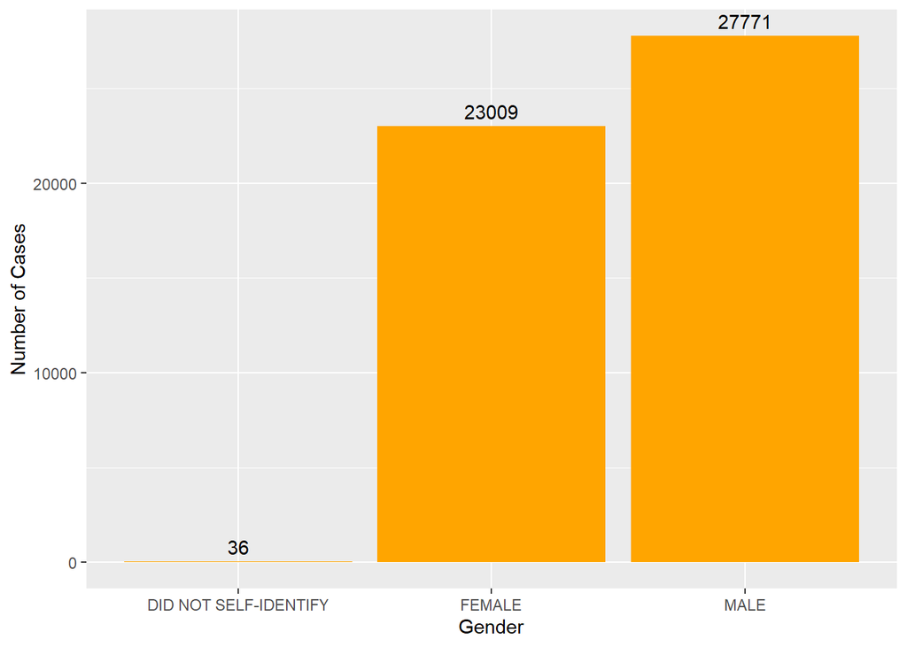

## Number of Cases by Age

### Age at Start of Application

This section looks at the number of cases by the age of the client when the case was started.

Initially I put the data into a bar graph but it is difficult to read the various ages and the bar labels are crowded.

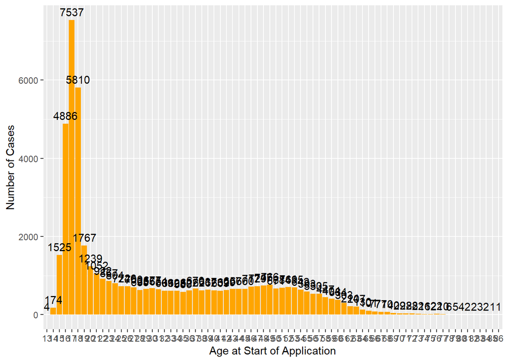

I then looked at a table of the data sorted by the number of cases which was more helpful.

From this table we can see that the majority of cases were from those in their mid teen to mid twenties (as could be seen in the bar graph).

```
## # A tibble: 74 x 2
## # Groups:   Age.at.Application [74]
##    Age.at.Application Total.Cases
##                 <int>       <int>
##  1                 17        7537
##  2                 18        5810
##  3                 16        4886
##  4                 19        1767
##  5                 15        1525
##  6                 20        1239
##  7                 21        1052
##  8                 22         922
##  9                 23         867
## 10                 24         804
## # ... with 64 more rows
```

This section looks at the number of cases by the age of the client when the case was closed.

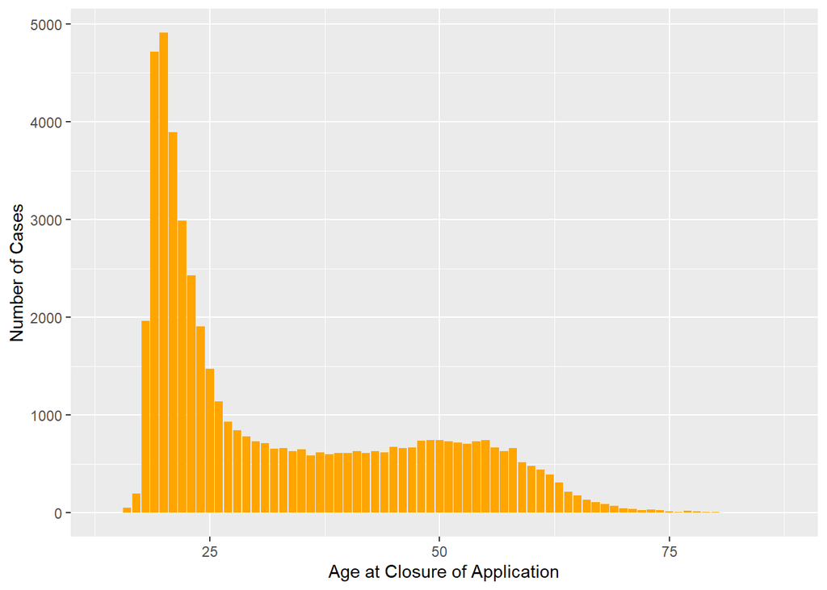

I then looked at a table of the data sorted by the number of cases.

From this table we can see that the majority of cases were actually from those in their late teen to late twenties.

```
## # A tibble: 74 x 2
## # Groups:   Age.at.Closure [74]
##    Age.at.Closure Total.Cases
##             <int>       <int>
##  1             20        4910
##  2             19        4716
##  3             21        3891
##  4             22        2990
##  5             23        2427
##  6             18        1962
##  7             24        1907
##  8             25        1472
##  9             26        1140
## 10             27         930
## # ... with 64 more rows
```

I then looked at the age span of the cases by subtracting the persons age at the end of their case from their age at the start of the case.

We can see that the majority of the cases were only open for 1 - 3 years. This makes sense since from our previous graphs it appeared that those in the majority age range for their case start age were in the majority for their case closed age.

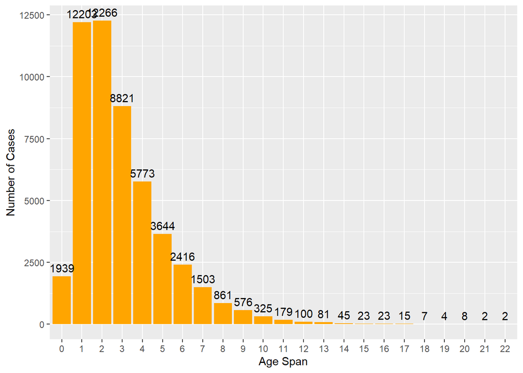

## Minority Groups

This section looks at the minority groups. We can see that the most of the cases were non-minority clients.

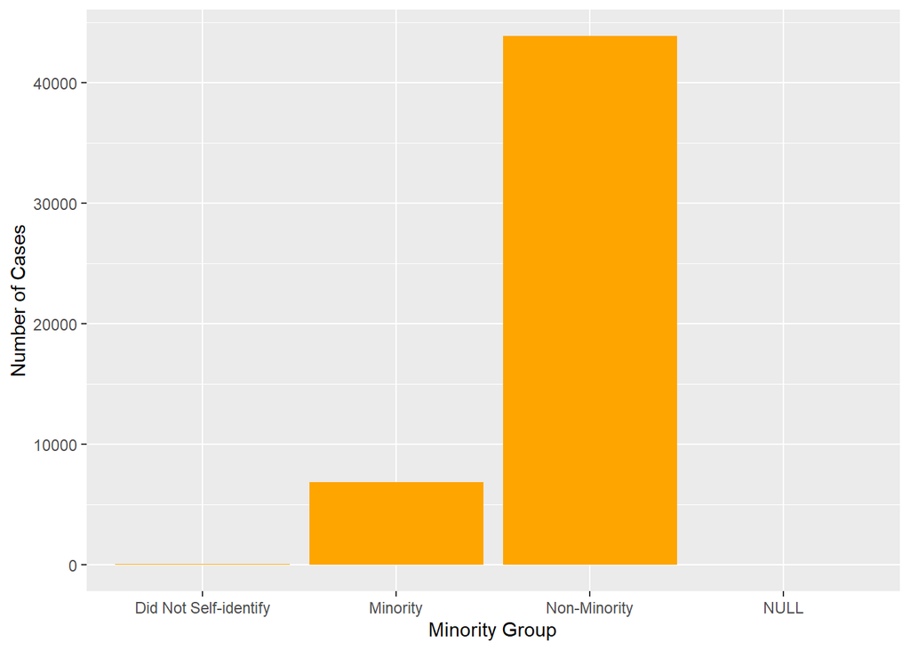

## Monthly Cases

This section looks at how long the closed cases were opened. I created a bar chart to view this data, however there are a large number of data points and it is difficult to see specifics. We can see that the majority of cases were opened between about 10 - 50 months (about 1 - 5 years).

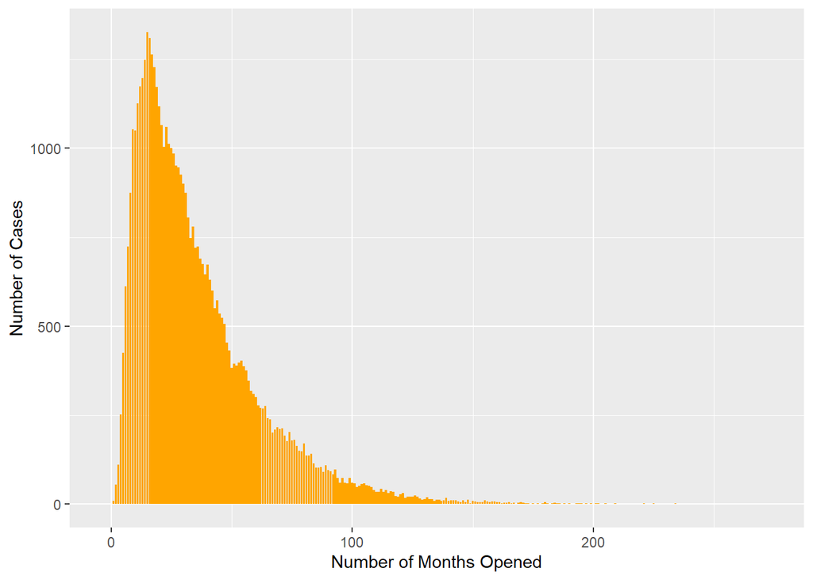

```
## # A tibble: 224 x 2
## # Groups:   Months.Case.Open [224]
##    Months.Case.Open Total.Cases
##               <int>       <int>
##  1               15        1326
##  2               16        1310
##  3               17        1263
##  4               14        1249
##  5               18        1228
##  6               13        1197
##  7               12        1173
##  8               19        1171
##  9               11        1126
## 10               20        1118
## # ... with 214 more rows
```

## Yearly Cases

This section looks at how many cases were closed each year. We can see that the number of closed cases has remained relatively the same over the course of the data sets history.

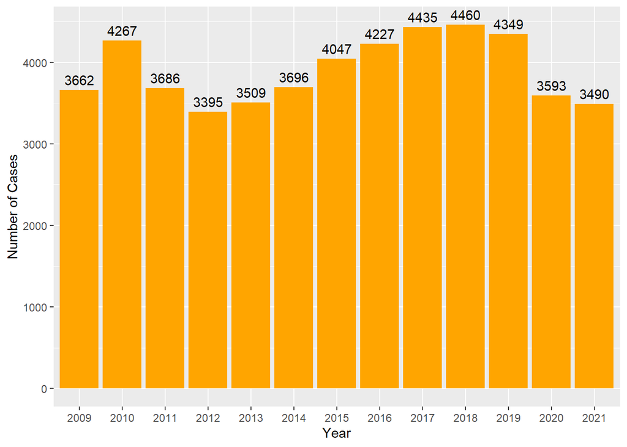

## Cases by Client County

This section looks at the clients for each case by county they are from. Initially I attempted to make a bar chart hoping it would hold all of Iowa’s 99 counties. However I learned that there are many counties in the data set outside of Iowa which made it almost imbossible to view that data in a bar graph format.

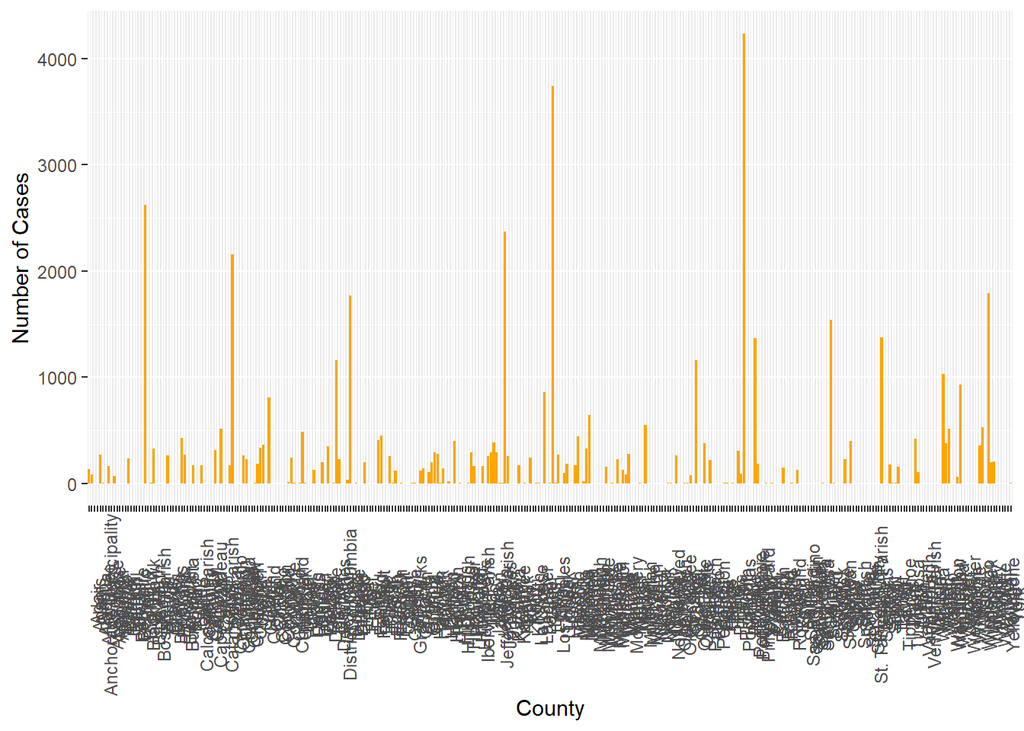

I then opted to make a table showing the number of closed cases for each county sorted by those with the highest number of cases. From this table we can see that Polk and Linn counties have the most closed cases. A quick Google search showed that the counties with the highest population were Polk and Linn so this data aligns with what we would expect.

```
## # A tibble: 329 x 2
## # Groups:   Client.County [329]
##    Client.County Total.Cases
##    <chr>               <int>
##  1 Polk                 4238
##  2 Linn                 3744
##  3 Black Hawk           2622
##  4 Johnson              2374
##  5 Cerro Gordo          2158
##  6 Woodbury             1794
##  7 Dubuque              1772
##  8 Scott                1542
##  9 Story                1374
## 10 Pottawattamie        1369
## # ... with 319 more rows
```

# Cases by Office Area

This section looks at the number of closed cases by the office area.

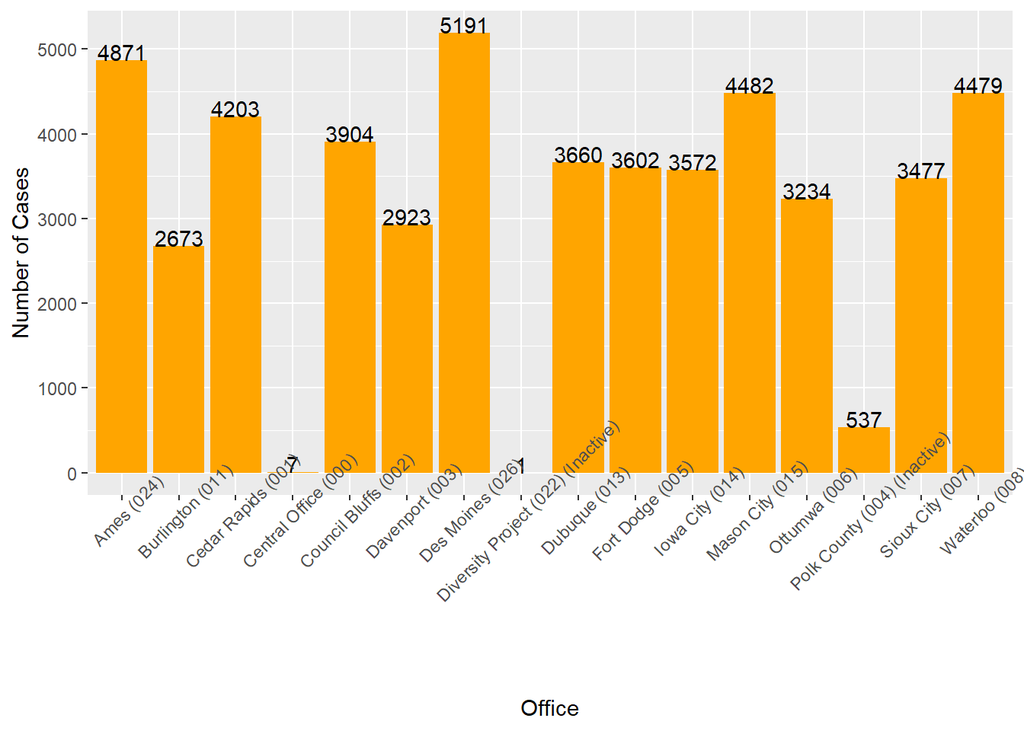